# CSC 578 Final

## Compiling and Training Models

Similarly to the tutorial, the process for compiling and training models are packaged into a function for convenience. This function is a modified version of the tutorial's function.

```python
#(bp) Modified version of tutorial's compile_and_fit() function
#(bp) patience was increased to 3 epochs
#(bp) Max number of epochs is 50

def compile_and_fit(model, window, patience=3):
  early_stopping = tf.keras.callbacks.EarlyStopping(monitor='val_loss',
                                                    patience=patience,
                                                    mode='min')

  model.compile(loss=tf.losses.MeanSquaredError(),
                optimizer=tf.optimizers.Adam(),
                metrics=[tf.metrics.MeanAbsoluteError()])

  history = model.fit(window.train, epochs=50,
                      validation_data=window.val,
                      callbacks=[early_stopping])

  return history
```

## Setting up the Window

The task calls for using a 6-hour window to predict the traffic volume 2 hours past that window. This window will yield 1 output.

```python
#Window for df_all dataset
task_all= WindowGenerator(
    input_width=6, label_width=1, shift=2,
    train_df= train_df_all,
    val_df= val_df_all,
    test_df= test_df_all,
    label_columns=['traffic_volume']
)

#Window for df_main dataset
task_main= WindowGenerator(
    input_width=6, label_width=1, shift=2,
    train_df= train_df_main,
    val_df= val_df_main,
    test_df= test_df_main,
    label_columns=['traffic_volume']
)

#Window for df_desc dataset
task_desc= WindowGenerator(
    input_width=6, label_width=1, shift=2,
    train_df= train_df_desc,
    val_df= val_df_desc,
    test_df= test_df_desc,
    label_columns=['traffic_volume']
)
```

## Baseline

The goal of this project is to develop a RNN model that predicts traffic volume over a timeseries. In order to get sense of how the different models may perform a simple RNN-LSTM baseline model will be used. This baseline model will consist of a single RNN-LSTM layer with 1 unit and a 1 unit Dense output layer.

### Training Baseline: df_all

```python
baseline = tf.keras.models.Sequential([
    tf.keras.layers.LSTM(1, return_sequences=False),
    tf.keras.layers.Dense(1)
])
```

```python
history= compile_and_fit(baseline, task_all)
```

#### Evaluating the baseline performance: df_all

```
360/360 - 1s - loss: 0.0101 - mean_absolute_error: 0.0756
valid_mae=0.0755789577960968, valid_loss=0.010138078592717648
```

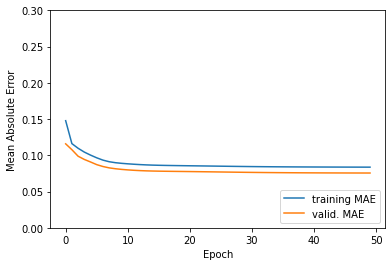

```python
#Evaluating model
plt.plot(history.history['mean_absolute_error'], label='training MAE')
plt.plot(history.history['val_mean_absolute_error'], label = 'valid. MAE')
plt.xlabel('Epoch')
plt.ylabel('Mean Absolute Error')
plt.ylim([0, .3])
plt.legend(loc='lower right')

# Evaluate the learned model with validation set
valid_loss, valid_mae = baseline.evaluate(task_all.val, verbose=2)
print ("valid_mae=%s, valid_loss=%s" % (valid_mae, valid_loss))
```

### Training Baseline: df_main

```python
baseline = tf.keras.models.Sequential([
    tf.keras.layers.LSTM(1, return_sequences=False),
    tf.keras.layers.Dense(1)
])
```

```python
history= compile_and_fit(baseline, task_main)
```

#### Evaluating the baseline performance: df_main

```
360/360 - 1s - loss: 0.0103 - mean_absolute_error: 0.0735
valid_mae=0.0735187977552414, valid_loss=0.010262217372655869
```

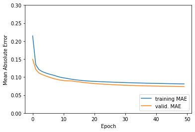

```python
#Evaluating model
plt.plot(history.history['mean_absolute_error'], label='training MAE')
plt.plot(history.history['val_mean_absolute_error'], label = 'valid. MAE')
plt.xlabel('Epoch')
plt.ylabel('Mean Absolute Error')
plt.ylim([0, .3])
plt.legend(loc='lower right')

# Evaluate the learned model with validation set
valid_loss, valid_mae = baseline.evaluate(task_main.val, verbose=2)
print ("valid_mae=%s, valid_loss=%s" % (valid_mae, valid_loss))
```

### Training Baseline: df_desc

```python
baseline = tf.keras.models.Sequential([
    tf.keras.layers.LSTM(1, return_sequences=False),
    tf.keras.layers.Dense(1)
])
```

```python
history= compile_and_fit(baseline, task_desc)
```

#### Evaluating the baseline performance: df_desc

```
360/360 - 1s - loss: 0.0090 - mean_absolute_error: 0.0712
valid_mae=0.07120909541845322, valid_loss=0.008976130746304989
```

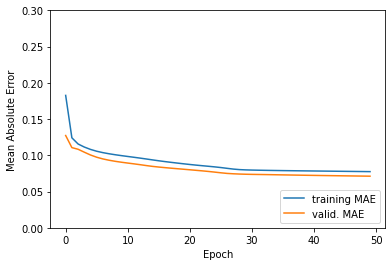

```python
#Evaluating model
plt.plot(history.history['mean_absolute_error'], label='training MAE')
plt.plot(history.history['val_mean_absolute_error'], label = 'valid. MAE')
plt.xlabel('Epoch')
plt.ylabel('Mean Absolute Error')
plt.ylim([0, .3])
plt.legend(loc='lower right')

# Evaluate the learned model with validation set
valid_loss, valid_mae = baseline.evaluate(task_desc.val, verbose=2)
print ("valid_mae=%s, valid_loss=%s" % (valid_mae, valid_loss))
```

The baseline model was applied to each of the 3 datasets. The dataset producing the best results in the baseline evaluation is the dataset containing only weather description variables, df_desc. The difference was quite small and could be a result of the random initialization, but the performance over a few trials was enough to choose it as the primary dataset for model optimization going forward.

## Optimization Trials

Different model architectures will be evaluated in an attempt to improve RNN-LSTM performance on the traffic data.

**Baseline Validation MAE: .0712**

### Alternate Model

```python
alter = tf.keras.models.Sequential([
    tf.keras.layers.Conv1D(24, kernel_size=3),
    tf.keras.layers.LSTM(12, return_sequences=True),
    tf.keras.layers.LSTM(24, return_sequences=True),
    tf.keras.layers.LSTM(48, return_sequences=True),
    tf.keras.layers.LSTM(72, return_sequences=False),
    tf.keras.layers.Dense(1, kernel_initializer= tf.keras.initializers.zeros())
])
```

```python
history= compile_and_fit(alter, task_desc)
```

```
360/360 - 2s - loss: 0.0048 - mean_absolute_error: 0.0477
valid_mae=0.0477362759411335, valid_loss=0.004792600404471159
```

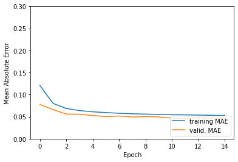

```python
#Evaluating model
plt.plot(history.history['mean_absolute_error'], label='training MAE')
plt.plot(history.history['val_mean_absolute_error'], label = 'valid. MAE')
plt.xlabel('Epoch')
plt.ylabel('Mean Absolute Error')
plt.ylim([0, .3])
plt.legend(loc='lower right')

# Evaluate the learned model with validation set
valid_loss, valid_mae = alter.evaluate(task_desc.val, verbose=2)
print ("valid_mae=%s, valid_loss=%s" % (valid_mae, valid_loss))
```

### Best Model

```python
trial = tf.keras.models.Sequential([
    tf.keras.layers.Conv1D(12, kernel_size=3),
    tf.keras.layers.LSTM(24, return_sequences=True),
    tf.keras.layers.LSTM(48, return_sequences=False),
    tf.keras.layers.Dense(1, kernel_initializer= tf.keras.initializers.zeros())
])
```

```python
history= compile_and_fit(trial, task_desc)
```

```
360/360 - 1s - loss: 0.0046 - mean_absolute_error: 0.0458
valid_mae=0.045840661972761154, valid_loss=0.00458289822563529
```

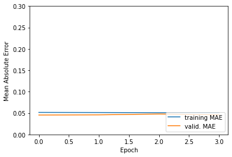

```python
#Evaluating model
plt.plot(history.history['mean_absolute_error'], label='training MAE')
plt.plot(history.history['val_mean_absolute_error'], label = 'valid. MAE')
plt.xlabel('Epoch')
plt.ylabel('Mean Absolute Error')
plt.ylim([0, .3])
plt.legend(loc='lower right')

# Evaluate the learned model with validation set
valid_loss, valid_mae = trial.evaluate(task_desc.val, verbose=2)
print ("valid_mae=%s, valid_loss=%s" % (valid_mae, valid_loss))
```

**Evaluating batch size**  
Trial 1, Batch size 24: .0532

Trial 2, Batch size 48: .0557

**Evaluating Recurrent Units**  
Trial 3, 64 units: .0502

Trial 4, 128 units: .0504

Trial 5, 48 units: .0485

**Evaluating Stacked Recurrent Layers**  
Trial 6, 2 layers, 48 units: .0470

Trial 7, 3 layers, 48 units: .0471

**Evaluating 1D Convolution + RNN**  
Trial 8, 1 conv(32) + 2 RNN(48): .0475

Trial 9, 1 conv(32) + 2 RNN (48, 64): .0456

Trial 10, 1 conv(24) + 2 RNN (48,48): .0449

## Test Predictions

```python
#Make predictions on test data
predictions= trial.predict(task_desc.test)
predictions
```

```
array([[0.16024166],
       [0.161432  ],
       [0.13348353],
       ...,
       [0.38290703],
       [0.32562226],
       [0.22314161]], dtype=float32)
```

```python
#De-Normalize the traffic volume predictions
p= pd.DataFrame(predictions, index= list(range(1,len(predictions)+1)), columns= ['prediction'])
p= (p * mm_range['traffic_volume']) + train_min['traffic_volume']
p
```

|  | prediction |
| --- | --- |
| 1 | 1166.559326 |
| 2 | 1175.224976 |
| 3 | 971.760071 |
| 4 | 820.596802 |
| 5 | 501.189453 |
| ... | ... |
| 4989 | 3257.278320 |
| 4990 | 3131.484619 |
| 4991 | 2787.563232 |
| 4992 | 2370.530029 |
| 4993 | 1624.470947 |

4993 rows × 1 columns

```python
#Creating csv from predictions with appropriate index and header for kaggle submission
p.to_csv('trial13.csv',index=True, index_label='id', header= True)
```